# MK2 Validation Analysis

Karthik SUresh

9/30/2020

# Data Import and cleaning

The data for these analyses came from cBioPortal. We downloaded the clinical data as tracks from the website along with mRNA data. The mRNA data was available in 2 forms: log-normalized to other genes, or non-scaled - i.e. log normalized RSEM expression that is not normalized to other genes. We chose to use the latter (although on comparison, the difference in actual values between the two forms of mRNA data was minimal, and did not significantly change our model results)

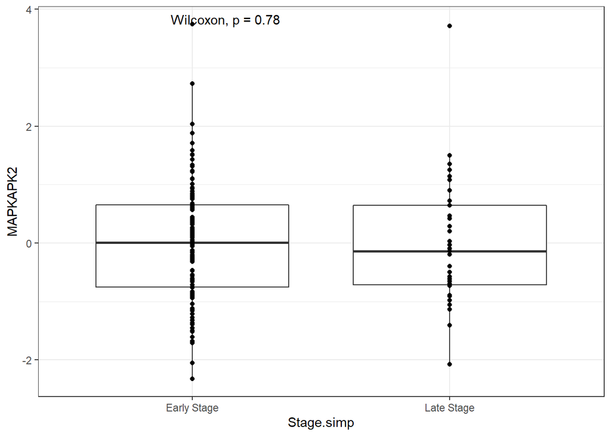

```r
knitr::opts_chunk$set(echo = TRUE)
library(data.table)
library(ggplot2)
library(ggpubr)
library(dplyr)
library(survival)
library(survminer)
# This is MAPKAPK2 mRNA and survival data obtained from cBioBortal - Study: OncoSG, Nat Genetics 2020

MK2_valid <- read.table("../rawdata/validation.dataset.MK2.Exp.tsv", sep="\t")

# these are normalized across the genome. We want the non-scaled data
MK2_valid_nn <- read.csv("../rawdata/MAPKAPK2_valid_mRNA_nonnorm.txt", sep="\t")
MK2_valid <- MK2_valid[c(1:8,14),]
MK2_valid_t <- transpose(MK2_valid)
colnames(MK2_valid_t) <- MK2_valid_t[1,]
MK2_valid_t <- MK2_valid_t[-c(1:2), ]
MK2_valid_t <- left_join(MK2_valid_t, MK2_valid_nn, by=c("track_name"="Patient.ID"))

# switch the expression over to the non-scaled version
MK2_valid_t$MAPKAPK2 <- MK2_valid_t$MAPKAPK2..mRNA.Expression..log.RNA.Seq.V2.RSEM.

MK2_valid_t$Stage.simp <- lapply(MK2_valid_t$Stage, function(x) if(x=="I" | x=="II") return("Early Stage") else return("Late Stage"))
MK2_valid_t$Stage.simp <- as.factor(unlist(MK2_valid_t$Stage.simp))
MK2_valid_t$MAPKAPK2 <- as.numeric(MK2_valid_t$MAPKAPK2)

# MK2 expression levels
ggplot(MK2_valid_t, aes(x=Stage.simp, y=MAPKAPK2))+geom_boxplot(outlier.shape = NA)+geom_point()+theme_bw()+stat_compare_means()
```

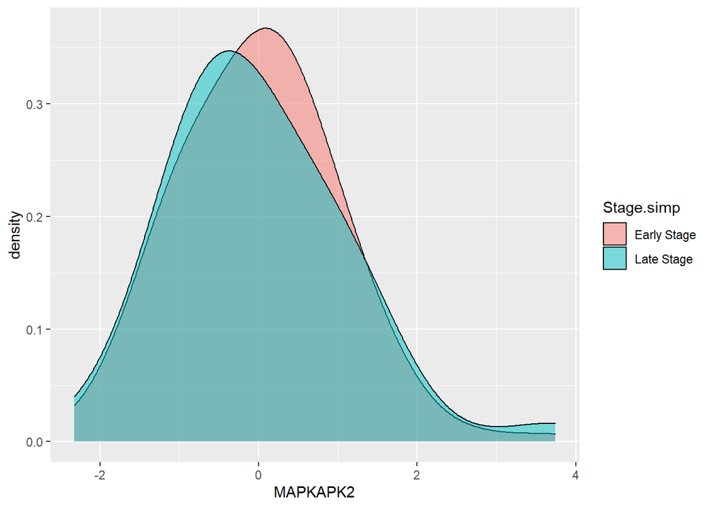

```r
ggplot(MK2_valid_t, aes(x=MAPKAPK2, fill=Stage.simp))+geom_density(adjust=1.5, alpha=0.5)
```

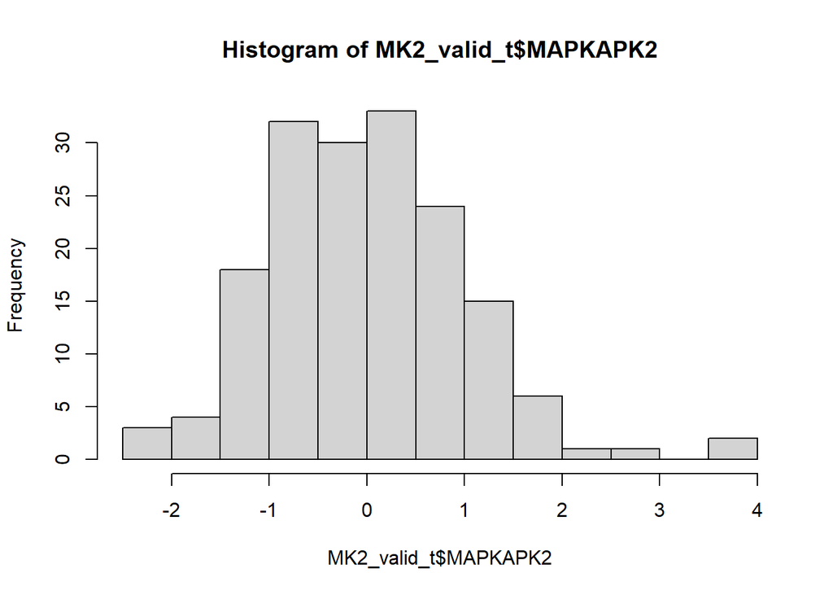

```r
hist(MK2_valid_t$MAPKAPK2)
```

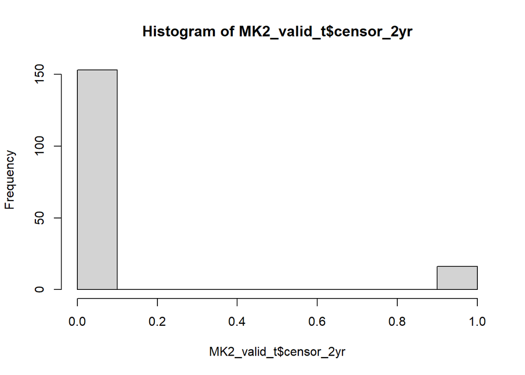

```r
# new variables for cox ph analysis
MK2_valid_t$censor <- lapply(MK2_valid_t$`Overall survival status`, function(x) if(x=="0:LIVING") return(0) else return(1))
MK2_valid_t$time <-as.numeric(MK2_valid_t$`Overall survival months`)
MK2_valid_t$censor <-as.numeric(unlist(MK2_valid_t$censor))
MK2_valid_t$time <- as.numeric(MK2_valid_t$time)
MK2_valid_t$Sex <- as.factor(MK2_valid_t$Sex)
MK2_valid_t$Stage <- as.factor(MK2_valid_t$Stage)
MK2_valid_t$Smoking <- as.factor(MK2_valid_t$`Smoking status`)
MK2_valid_t$Age <- as.numeric(MK2_valid_t$Age)

# R censoring variable
# The problem is that there are very few events (deaths) at one year. So we can't R censor at 1 year like we did previously. So, we will try 2 years.
MK2_valid_t$censor_2yr <- mapply(function(dead,time) if(dead==1 & time <25) return(1) else if(dead==0 & time > 24) return(0) else if (dead==0 & time < 25) return(0) else if (dead==1 & time > 24) return(0),MK2_valid_t$censor, MK2_valid_t$time )
MK2_valid_t$censor_2yr <- as.numeric(unlist(MK2_valid_t$censor_2yr))


hist(MK2_valid_t$censor_2yr)
```

# Cox PH analysis with R censoring at 2 years

This will be done in two forms - using MK2 as a continuous variable, and again using top 1/3 vs. bottom 2/3 MK2 levels.

```r
# MK2 survival analysis using R censoring at 1 year
summary(coxph(Surv(time, censor_2yr) ~ MAPKAPK2, id=Sample.ID, data=MK2_valid_t))
```

```
## Call:
## coxph(formula = Surv(time, censor_2yr) ~ MAPKAPK2, data = MK2_valid_t,
##     id = Sample.ID)
##
##   n= 169, number of events= 16
##
##             coef exp(coef) se(coef)      z Pr(>|z|)
## MAPKAPK2 -0.6548    0.5196   0.2796 -2.341   0.0192 *
## ---
## Signif. codes:  0 '***' 0.001 '**' 0.01 '*' 0.05 '.' 0.1 ' ' 1
##
##          exp(coef) exp(-coef) lower .95 upper .95
## MAPKAPK2    0.5196      1.925    0.3003    0.8988
##
## Concordance= 0.686  (se = 0.055 )
## Likelihood ratio test= 5.91  on 1 df,   p=0.02
## Wald test            = 5.48  on 1 df,   p=0.02
## Score (logrank) test = 5.38  on 1 df,   p=0.02
```

```r
summary(coxph(Surv(time, censor_2yr) ~ MAPKAPK2+Sex, id=Sample.ID, data=MK2_valid_t))
```

```
## Call:
## coxph(formula = Surv(time, censor_2yr) ~ MAPKAPK2 + Sex, data = MK2_valid_t,
##     id = Sample.ID)
##
##   n= 169, number of events= 16
##
##             coef exp(coef) se(coef)      z Pr(>|z|)
## MAPKAPK2 -0.7174    0.4880   0.2833 -2.532   0.0113 *
## SexMale   0.9137    2.4934   0.5204  1.756   0.0791 .
## ---
## Signif. codes:  0 '***' 0.001 '**' 0.01 '*' 0.05 '.' 0.1 ' ' 1
##
##          exp(coef) exp(-coef) lower .95 upper .95
## MAPKAPK2     0.488     2.0492    0.2801    0.8503
## SexMale      2.493     0.4011    0.8992    6.9145
##
## Concordance= 0.716  (se = 0.055 )
## Likelihood ratio test= 9.13  on 2 df,   p=0.01
## Wald test            = 8.55  on 2 df,   p=0.01
## Score (logrank) test = 8.26  on 2 df,   p=0.02
```

```r
summary(coxph(Surv(time, censor_2yr) ~ MAPKAPK2+Sex+Stage.simp, id=Sample.ID, data=MK2_valid_t))
```

```
## Call:
## coxph(formula = Surv(time, censor_2yr) ~ MAPKAPK2 + Sex + Stage.simp,
##     data = MK2_valid_t, id = Sample.ID)
##
##   n= 169, number of events= 16
##
##                         coef exp(coef) se(coef)      z Pr(>|z|)
## MAPKAPK2             -0.7861    0.4556   0.2984 -2.635  0.00842 **
## SexMale               0.9529    2.5933   0.5315  1.793  0.07299 .
## Stage.simpLate Stage  1.4174    4.1262   0.5032  2.816  0.00486 **
## ---
## Signif. codes:  0 '***' 0.001 '**' 0.01 '*' 0.05 '.' 0.1 ' ' 1
##
##                      exp(coef) exp(-coef) lower .95 upper .95
## MAPKAPK2                0.4556     2.1948    0.2539    0.8176
## SexMale                 2.5933     0.3856    0.9150    7.3497
## Stage.simpLate Stage    4.1262     0.2424    1.5388   11.0638
##
## Concordance= 0.795  (se = 0.044 )
## Likelihood ratio test= 16.5  on 3 df,   p=9e-04
## Wald test            = 14.81  on 3 df,   p=0.002
## Score (logrank) test = 16.91  on 3 df,   p=7e-04
```

```r
summary(coxph(Surv(time, censor_2yr) ~ MAPKAPK2+Age+Sex+Smoking+Stage.simp, id=Sample.ID, data=MK2_valid_t))
```

```
## Call:
## coxph(formula = Surv(time, censor_2yr) ~ MAPKAPK2 + Age + Sex +
##     Smoking + Stage.simp, data = MK2_valid_t, id = Sample.ID)
##
##   n= 169, number of events= 16
##
##                          coef exp(coef) se(coef)      z Pr(>|z|)
## MAPKAPK2             -0.90164   0.40590  0.30940 -2.914  0.00357 **
## Age                   0.03292   1.03346  0.02668  1.234  0.21722
## SexMale               0.08766   1.09162  0.61359  0.143  0.88640
## SmokingYes            1.63958   5.15300  0.65482  2.504  0.01228 *
## Stage.simpLate Stage  1.49883   4.47645  0.51553  2.907  0.00365 **
## ---
## Signif. codes:  0 '***' 0.001 '**' 0.01 '*' 0.05 '.' 0.1 ' ' 1
##
##                      exp(coef) exp(-coef) lower .95 upper .95
## MAPKAPK2                0.4059     2.4636    0.2213    0.7444
## Age                     1.0335     0.9676    0.9808    1.0889
## SexMale                 1.0916     0.9161    0.3279    3.6338
## SmokingYes              5.1530     0.1941    1.4278   18.5970
## Stage.simpLate Stage    4.4764     0.2234    1.6297   12.2958
##
## Concordance= 0.827  (se = 0.046 )
## Likelihood ratio test= 24.36  on 5 df,   p=2e-04
## Wald test            = 19.58  on 5 df,   p=0.001
## Score (logrank) test = 23.71  on 5 df,   p=2e-04
```

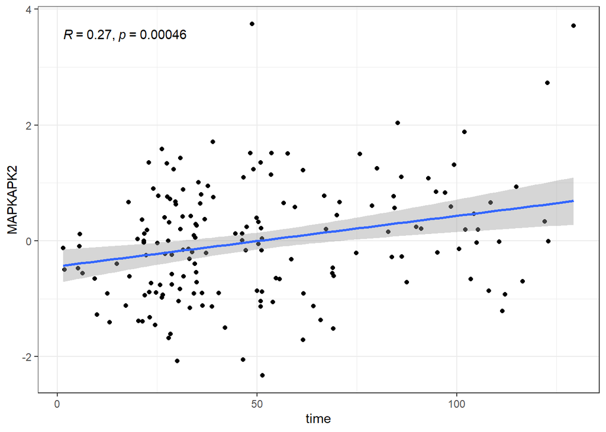

```r
MK2_CoxPH_valid_RC <- coxph(Surv(time, censor_2yr) ~ MAPKAPK2+Age+Sex+Smoking+Stage.simp, id=Sample.ID, data=MK2_valid_t)

ggplot(MK2_valid_t, aes(x=time, y=MAPKAPK2))+geom_point()+geom_smooth(method="lm")+theme_bw()+stat_cor()
```

```r
cox.zph(MK2_CoxPH_valid_RC)
```

```
##            chisq df    p
## MAPKAPK2   0.117  1 0.73
## Age        0.624  1 0.43
## Sex        1.305  1 0.25
## Smoking    0.910  1 0.34
## Stage.simp 0.681  1 0.41
## GLOBAL     2.783  5 0.73
```

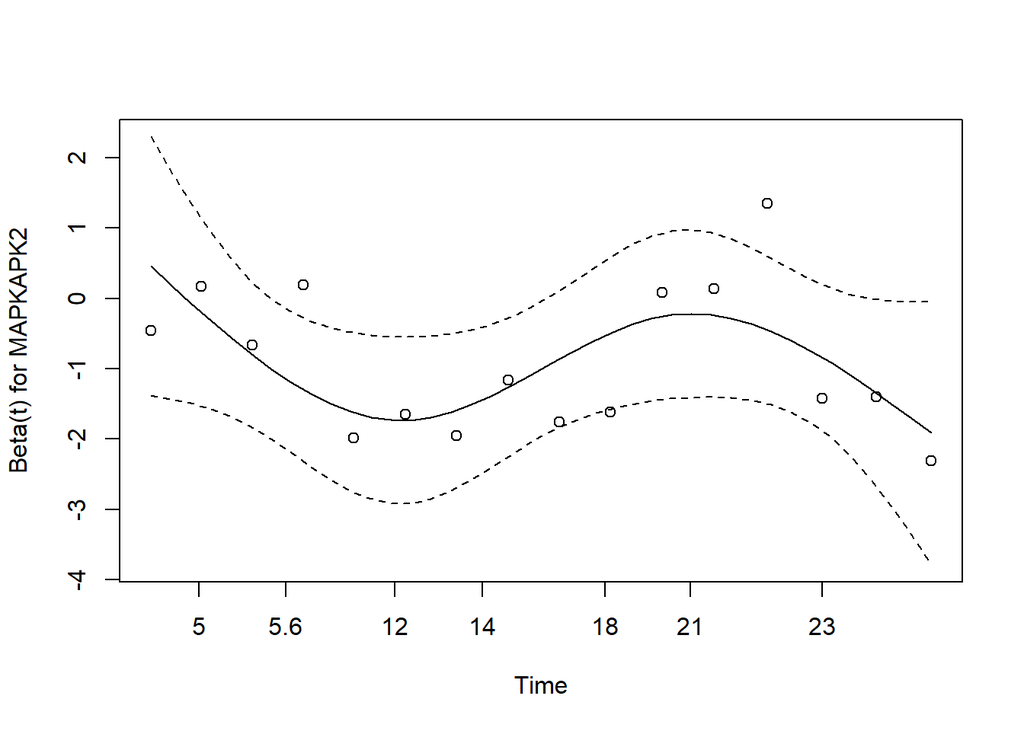

```r
plot(cox.zph(MK2_CoxPH_valid_RC)[1])
```

```r
summary(MK2_CoxPH_valid_RC)
```

```
## Call:
## coxph(formula = Surv(time, censor_2yr) ~ MAPKAPK2 + Age + Sex +
##     Smoking + Stage.simp, data = MK2_valid_t, id = Sample.ID)
##
##   n= 169, number of events= 16
##
##                          coef exp(coef) se(coef)      z Pr(>|z|)
## MAPKAPK2             -0.90164   0.40590  0.30940 -2.914  0.00357 **
## Age                   0.03292   1.03346  0.02668  1.234  0.21722
## SexMale               0.08766   1.09162  0.61359  0.143  0.88640
## SmokingYes            1.63958   5.15300  0.65482  2.504  0.01228 *
## Stage.simpLate Stage  1.49883   4.47645  0.51553  2.907  0.00365 **
## ---
## Signif. codes:  0 '***' 0.001 '**' 0.01 '*' 0.05 '.' 0.1 ' ' 1
##
##                      exp(coef) exp(-coef) lower .95 upper .95
## MAPKAPK2                0.4059     2.4636    0.2213    0.7444
## Age                     1.0335     0.9676    0.9808    1.0889
## SexMale                 1.0916     0.9161    0.3279    3.6338
## SmokingYes              5.1530     0.1941    1.4278   18.5970
## Stage.simpLate Stage    4.4764     0.2234    1.6297   12.2958
##
## Concordance= 0.827  (se = 0.046 )
## Likelihood ratio test= 24.36  on 5 df,   p=2e-04
## Wald test            = 19.58  on 5 df,   p=0.001
## Score (logrank) test = 23.71  on 5 df,   p=2e-04
```

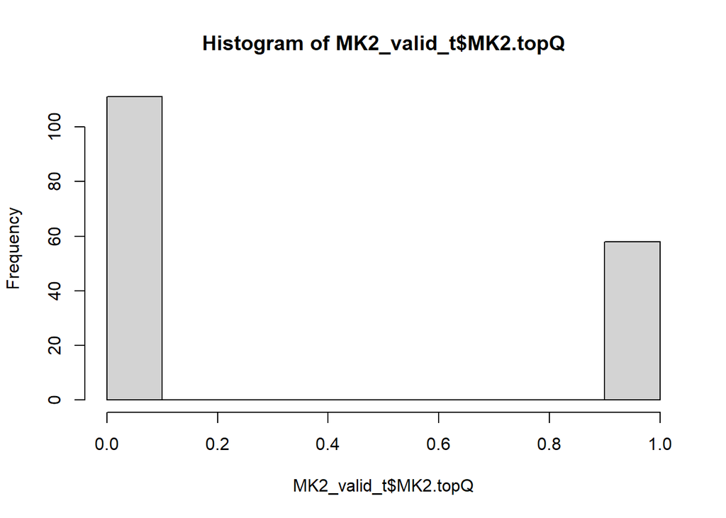

```r
# Repeat analysis with quantiles

MK2_valid_t$MK2.topQ <- lapply(MK2_valid_t$MAPKAPK2, function(x) if(x > quantile(MK2_valid_t$MAPKAPK2,  0.66)) return(1) else return(0))
MK2_valid_t$MK2.topQ <- as.numeric(unlist(MK2_valid_t$MK2.topQ))
hist(MK2_valid_t$MK2.topQ)
```

```r
MK2_CoxPH_valid_RC_topQ <- coxph(Surv(time, censor_2yr) ~ MK2.topQ+Age+Sex+Smoking+Stage.simp, id=Sample.ID, data=MK2_valid_t)
cox.zph(MK2_CoxPH_valid_RC_topQ)
```

```
##            chisq df    p
## MK2.topQ   0.849  1 0.36
## Age        0.493  1 0.48
## Sex        1.393  1 0.24
## Smoking    0.769  1 0.38
## Stage.simp 0.596  1 0.44
## GLOBAL     3.335  5 0.65
```

```r
summary(MK2_CoxPH_valid_RC_topQ)
```

```
## Call:
## coxph(formula = Surv(time, censor_2yr) ~ MK2.topQ + Age + Sex +
##     Smoking + Stage.simp, data = MK2_valid_t, id = Sample.ID)
##
##   n= 169, number of events= 16
##
##                          coef exp(coef) se(coef)      z Pr(>|z|)
## MK2.topQ             -2.24096   0.10636  1.03755 -2.160  0.03078 *
## Age                   0.02850   1.02891  0.02482  1.148  0.25087
## SexMale               0.26098   1.29820  0.59959  0.435  0.66337
## SmokingYes            1.23779   3.44798  0.62527  1.980  0.04775 *
## Stage.simpLate Stage  1.33972   3.81799  0.50235  2.667  0.00766 **
## ---
## Signif. codes:  0 '***' 0.001 '**' 0.01 '*' 0.05 '.' 0.1 ' ' 1
##
##                      exp(coef) exp(-coef) lower .95 upper .95
## MK2.topQ                0.1064     9.4024   0.01392    0.8127
## Age                     1.0289     0.9719   0.98005    1.0802
## SexMale                 1.2982     0.7703   0.40084    4.2045
## SmokingYes              3.4480     0.2900   1.01235   11.7435
## Stage.simpLate Stage    3.8180     0.2619   1.42637   10.2197
##
## Concordance= 0.836  (se = 0.043 )
## Likelihood ratio test= 23.95  on 5 df,   p=2e-04
## Wald test            = 19.84  on 5 df,   p=0.001
## Score (logrank) test = 24.04  on 5 df,   p=2e-04
```

```r
# Logistic regression for death at 2 year
glm_valid_RC_topQ <-glm(censor_2yr ~ MK2.topQ+Age+Sex+Smoking+Stage.simp, data=MK2_valid_t, family=binomial(link="logit"))
ResourceSelection::hoslem.test(glm_valid_RC_topQ$y, fitted(glm_valid_RC_topQ))
```

```
##
##  Hosmer and Lemeshow goodness of fit (GOF) test
##
## data:  glm_valid_RC_topQ$y, fitted(glm_valid_RC_topQ)
## X-squared = 5.1862, df = 8, p-value = 0.7375
```

```r
summary(glm_valid_RC_topQ)
```

```
##
## Call:
## glm(formula = censor_2yr ~ MK2.topQ + Age + Sex + Smoking + Stage.simp,
##     family = binomial(link = "logit"), data = MK2_valid_t)
##
## Deviance Residuals:
##      Min        1Q    Median        3Q       Max
## -1.39541  -0.44702  -0.25153  -0.09478   2.67335
##
## Coefficients:
##                      Estimate Std. Error z value Pr(>|z|)
## (Intercept)          -5.58292    2.03162  -2.748  0.00600 **
## MK2.topQ             -2.43052    1.08706  -2.236  0.02536 *
## Age                   0.03575    0.02906   1.230  0.21852
## SexMale               0.27854    0.69235   0.402  0.68746
## SmokingYes            1.47837    0.70376   2.101  0.03567 *
## Stage.simpLate Stage  1.60790    0.60011   2.679  0.00738 **
## ---
## Signif. codes:  0 '***' 0.001 '**' 0.01 '*' 0.05 '.' 0.1 ' ' 1
##
## (Dispersion parameter for binomial family taken to be 1)
##
##     Null deviance: 105.869  on 168  degrees of freedom
## Residual deviance:  81.567  on 163  degrees of freedom
## AIC: 93.567
##
## Number of Fisher Scoring iterations: 7
```

```r
exp(coefficients(glm_valid_RC_topQ))
```

```
##          (Intercept)             MK2.topQ                  Age
##          0.003761567          0.087990908          1.036401141
##              SexMale           SmokingYes Stage.simpLate Stage
##          1.321193700          4.385791796          4.992317722
```

```r
exp(confint(glm_valid_RC_topQ))
```

```
##                             2.5 %     97.5 %
## (Intercept)          4.839724e-05  0.1541378
## MK2.topQ             4.595678e-03  0.4995502
## Age                  9.810628e-01  1.1011159
## SexMale              3.394220e-01  5.2842893
## SmokingYes           1.153863e+00 18.8912207
## Stage.simpLate Stage 1.545490e+00 16.8396107
```

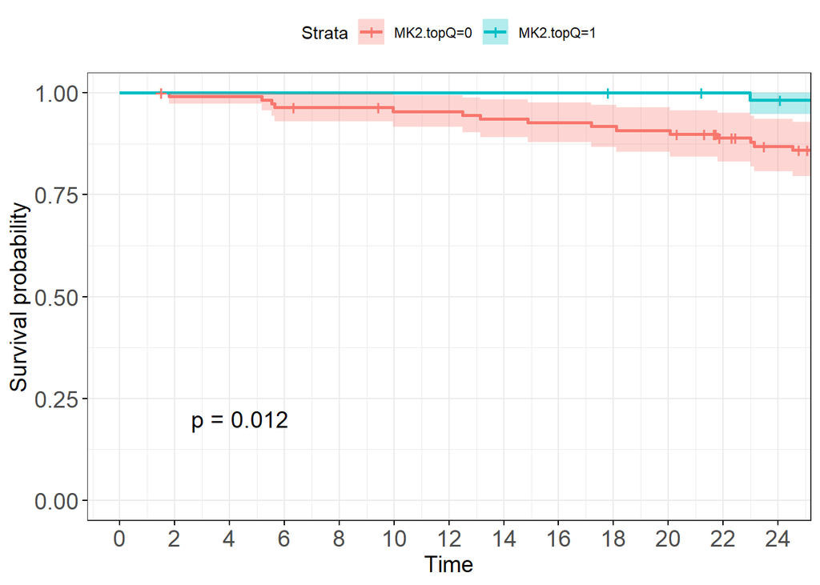

```r
km_valid <- survfit(Surv(time, censor_2yr)~MK2.topQ, data=MK2_valid_t, type='kaplan-meier')
ggsurvplot(km_valid, conf.int = TRUE, xlim=c(0,24), break.x.by=2,pval=TRUE, font.y=14,font.x=14,font.tickslab=14, ggtheme=theme_bw())
```

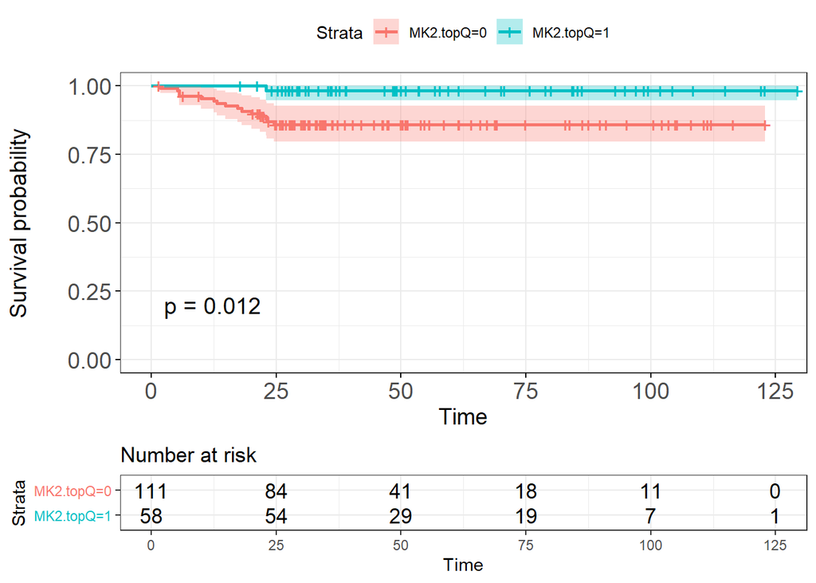

```r
ggsurvplot(km_valid, conf.int = TRUE,risk.table = TRUE, pval=TRUE, font.y=14,font.x=14,font.tickslab=14, ggtheme=theme_bw())
```

# Cox PH analysis without R censoring

Here, we’re going to entertain the entire dataset. We did this with TCGA as well.

## Initial Modeling

```r
# MK2 survival analysis using no R censoring at 1 year
summary(coxph(Surv(time, censor) ~ MAPKAPK2, id=Sample.ID, data=MK2_valid_t))
```

```
## Call:
## coxph(formula = Surv(time, censor) ~ MAPKAPK2, data = MK2_valid_t,
##     id = Sample.ID)
##
##   n= 169, number of events= 42
##
##             coef exp(coef) se(coef)      z Pr(>|z|)
## MAPKAPK2 -0.2783    0.7571   0.1576 -1.766   0.0774 .
## ---
## Signif. codes:  0 '***' 0.001 '**' 0.01 '*' 0.05 '.' 0.1 ' ' 1
##
##          exp(coef) exp(-coef) lower .95 upper .95
## MAPKAPK2    0.7571      1.321    0.5559     1.031
##
## Concordance= 0.618  (se = 0.041 )
## Likelihood ratio test= 3.27  on 1 df,   p=0.07
## Wald test            = 3.12  on 1 df,   p=0.08
## Score (logrank) test = 3.1  on 1 df,   p=0.08
```

```r
summary(coxph(Surv(time, censor) ~ MAPKAPK2+Sex, id=Sample.ID, data=MK2_valid_t))
```

```
## Call:
## coxph(formula = Surv(time, censor) ~ MAPKAPK2 + Sex, data = MK2_valid_t,
##     id = Sample.ID)
##
##   n= 169, number of events= 42
##
##             coef exp(coef) se(coef)      z Pr(>|z|)
## MAPKAPK2 -0.3150    0.7298   0.1633 -1.929   0.0537 .
## SexMale   0.6337    1.8846   0.3135  2.021   0.0433 *
## ---
## Signif. codes:  0 '***' 0.001 '**' 0.01 '*' 0.05 '.' 0.1 ' ' 1
##
##          exp(coef) exp(-coef) lower .95 upper .95
## MAPKAPK2    0.7298     1.3703    0.5299     1.005
## SexMale     1.8846     0.5306    1.0194     3.484
##
## Concordance= 0.665  (se = 0.041 )
## Likelihood ratio test= 7.38  on 2 df,   p=0.02
## Wald test            = 6.99  on 2 df,   p=0.03
## Score (logrank) test = 7  on 2 df,   p=0.03
```

```r
summary(coxph(Surv(time, censor) ~ MAPKAPK2+Sex+Stage.simp, id=Sample.ID, data=MK2_valid_t))
```

```
## Call:
## coxph(formula = Surv(time, censor) ~ MAPKAPK2 + Sex + Stage.simp,
##     data = MK2_valid_t, id = Sample.ID)
##
##   n= 169, number of events= 42
##
##                         coef exp(coef) se(coef)      z Pr(>|z|)
## MAPKAPK2             -0.3438    0.7091   0.1637 -2.100  0.03574 *
## SexMale               0.5874    1.7993   0.3171  1.852  0.06399 .
## Stage.simpLate Stage  0.9818    2.6694   0.3210  3.059  0.00222 **
## ---
## Signif. codes:  0 '***' 0.001 '**' 0.01 '*' 0.05 '.' 0.1 ' ' 1
##
##                      exp(coef) exp(-coef) lower .95 upper .95
## MAPKAPK2                0.7091     1.4102    0.5145    0.9773
## SexMale                 1.7993     0.5558    0.9664    3.3499
## Stage.simpLate Stage    2.6694     0.3746    1.4230    5.0075
##
## Concordance= 0.722  (se = 0.037 )
## Likelihood ratio test= 15.81  on 3 df,   p=0.001
## Wald test            = 15.97  on 3 df,   p=0.001
## Score (logrank) test = 17.16  on 3 df,   p=7e-04
```

```r
summary(coxph(Surv(time, censor) ~ MAPKAPK2+Age+Sex+Smoking+Stage.simp, id=Sample.ID, data=MK2_valid_t))
```

```
## Call:
## coxph(formula = Surv(time, censor) ~ MAPKAPK2 + Age + Sex + Smoking +
##     Stage.simp, data = MK2_valid_t, id = Sample.ID)
##
##   n= 169, number of events= 42
##
##                          coef exp(coef) se(coef)      z Pr(>|z|)
## MAPKAPK2             -0.34890   0.70546  0.16613 -2.100  0.03571 *
## Age                   0.01836   1.01853  0.01614  1.138  0.25522
## SexMale               0.33545   1.39856  0.37726  0.889  0.37392
## SmokingYes            0.41041   1.50743  0.37194  1.103  0.26984
## Stage.simpLate Stage  1.02244   2.77998  0.32276  3.168  0.00154 **
## ---
## Signif. codes:  0 '***' 0.001 '**' 0.01 '*' 0.05 '.' 0.1 ' ' 1
##
##                      exp(coef) exp(-coef) lower .95 upper .95
## MAPKAPK2                0.7055     1.4175    0.5094     0.977
## Age                     1.0185     0.9818    0.9868     1.051
## SexMale                 1.3986     0.7150    0.6677     2.930
## SmokingYes              1.5074     0.6634    0.7272     3.125
## Stage.simpLate Stage    2.7800     0.3597    1.4768     5.233
##
## Concordance= 0.724  (se = 0.04 )
## Likelihood ratio test= 17.96  on 5 df,   p=0.003
## Wald test            = 17.83  on 5 df,   p=0.003
## Score (logrank) test = 19.22  on 5 df,   p=0.002
```

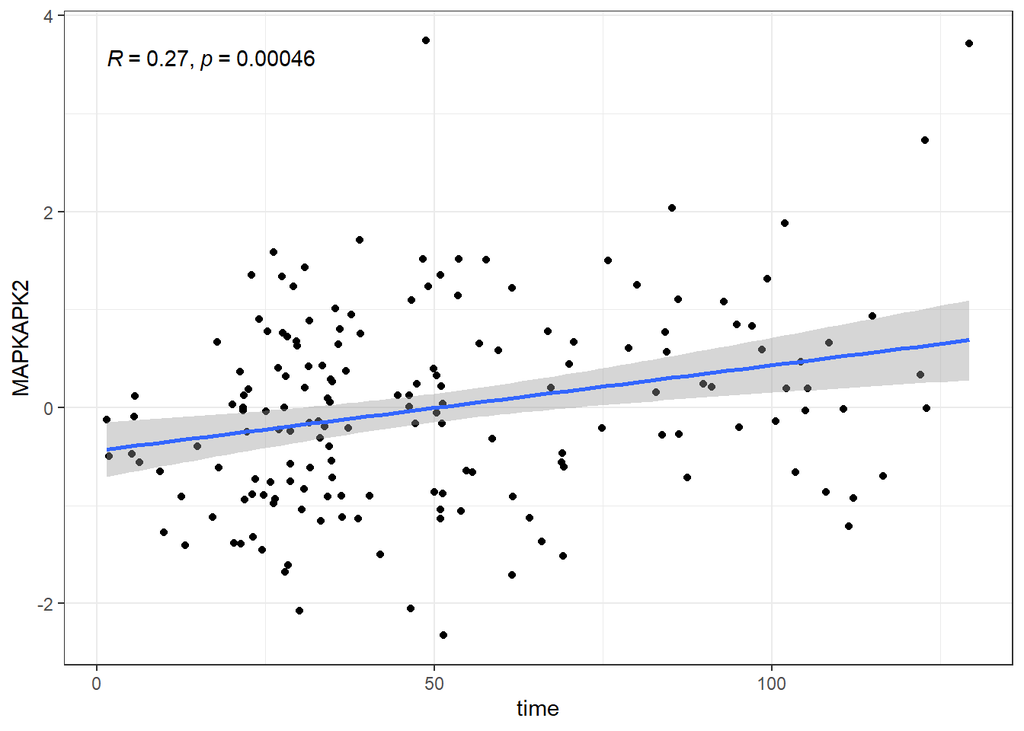

```r
MK2_CoxPH_valid <- coxph(Surv(time, censor) ~ MAPKAPK2+Age+Sex+Smoking+Stage.simp, id=Sample.ID, data=MK2_valid_t)

ggplot(MK2_valid_t, aes(x=time, y=MAPKAPK2))+geom_point()+geom_smooth(method="lm")+theme_bw()+stat_cor()
```

```r
cox.zph(MK2_CoxPH_valid)
```

```
##              chisq df     p
## MAPKAPK2    4.3060  1 0.038
## Age         0.0221  1 0.882
## Sex         1.5476  1 0.213
## Smoking     3.6507  1 0.056
## Stage.simp  1.3446  1 0.246
## GLOBAL     10.5683  5 0.061
```

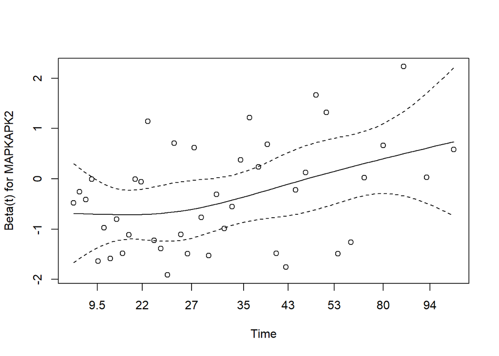

```r
# Hold up! There is an issue with the MAPKAPK2 variable.
plot(cox.zph(MK2_CoxPH_valid)[1])
```

```r
# let's look at model fit with log transformed time
model_fit <- cox.zph(MK2_CoxPH_valid, transform=function(time) log(time))

model_fit
```

```
##             chisq df     p
## MAPKAPK2   2.8372  1 0.092
## Age        0.0339  1 0.854
## Sex        0.1177  1 0.732
## Smoking    1.2931  1 0.255
## Stage.simp 1.4553  1 0.228
## GLOBAL     6.1553  5 0.291
```

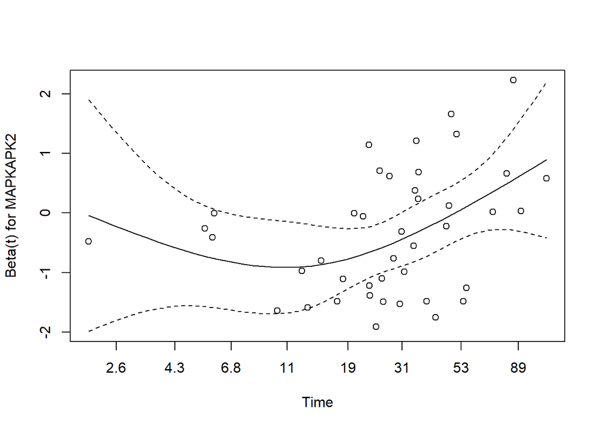

```r
plot(model_fit[1])
```

```r
# there is a linear dependence of the MAPKAPK variable to log time.
```

## Time-varying covariate handling - MAPKAPK2. Choosing the time transform function

When MAPKAPK is modeled with trational form, then we have L(t) = L0(t)exp(Bx(t)). But for time varying, we let the coeffcient b relate to time via the form b(t) = a+b*log(t). Now, b*x = x*(a+b*log(t)) = ax + blog(t)*x. a in the ax term is the beta from the MAPKAPK2 covariate, blog(t) is the beta from the tt() transformed MAPKAPK2 variable. So, the explanatory function a+[blog(t)]x can be plotted against the residuals/logtime plot to assess fit.

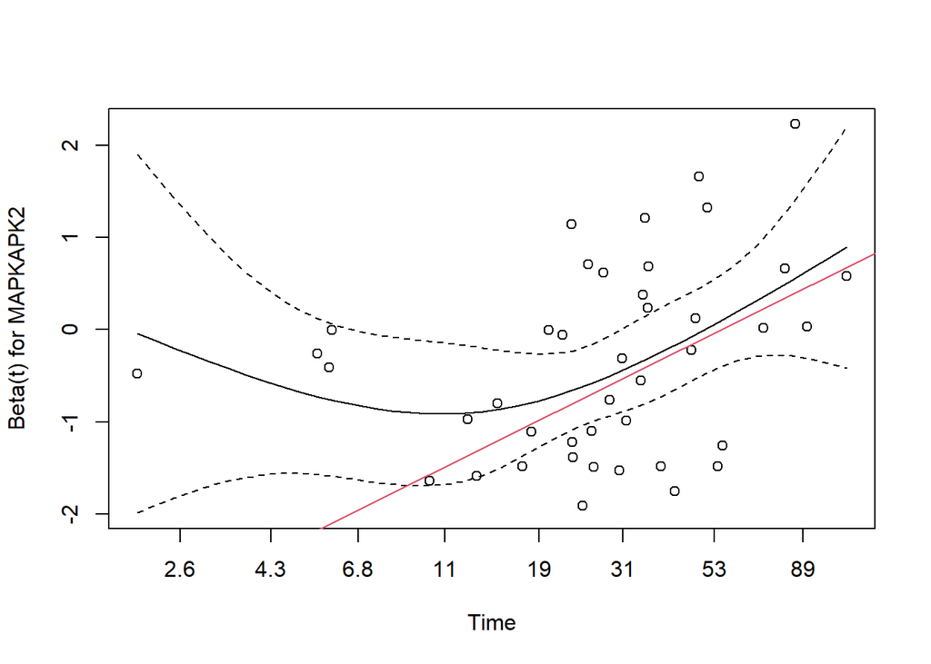

```
## integer(0)
```

```r
# multivariate model with tv variable
# here we fit the equation log(0.5*t+20) to model the relationship between MAPKAPK2 and time.

MK2_CoxPH_valid_tv <- coxph(Surv(time, censor) ~ Age+Sex+Smoking+Stage.simp+MAPKAPK2+tt(MAPKAPK2), id=Sample.ID, tt=function(x,t,...) x*log(0.5*t+20), data=MK2_valid_t)
plot(model_fit[1])+abline(coef(MK2_CoxPH_valid_tv)[5:6], col=2)
```

```r
summary(MK2_CoxPH_valid_tv)
```

```
## Call:
## coxph(formula = Surv(time, censor) ~ Age + Sex + Smoking + Stage.simp +
##     MAPKAPK2 + tt(MAPKAPK2), data = MK2_valid_t, tt = function(x,
##     t, ...) x * log(0.5 * t + 20), id = Sample.ID)
##
##   n= 169, number of events= 42
##
##                          coef exp(coef) se(coef)      z Pr(>|z|)
## Age                   0.01919   1.01937  0.01629  1.178  0.23880
## SexMale               0.35503   1.42623  0.38235  0.929  0.35312
## SmokingYes            0.45460   1.57555  0.37933  1.198  0.23074
## Stage.simpLate Stage  1.02379   2.78372  0.32455  3.155  0.00161 **
## MAPKAPK2             -3.69048   0.02496  1.74802 -2.111  0.03475 *
## tt(MAPKAPK2)          0.91986   2.50893  0.47567  1.934  0.05314 .
## ---
## Signif. codes:  0 '***' 0.001 '**' 0.01 '*' 0.05 '.' 0.1 ' ' 1
##
##                      exp(coef) exp(-coef) lower .95 upper .95
## Age                    1.01937     0.9810 0.9873431    1.0524
## SexMale                1.42623     0.7012 0.6741109    3.0175
## SmokingYes             1.57555     0.6347 0.7491146    3.3137
## Stage.simpLate Stage   2.78372     0.3592 1.4735711    5.2587
## MAPKAPK2               0.02496    40.0643 0.0008116    0.7676
## tt(MAPKAPK2)           2.50893     0.3986 0.9876267    6.3736
##
## Concordance= 0.728  (se = 0.04 )
## Likelihood ratio test= 21.6  on 6 df,   p=0.001
## Wald test            = 20.72  on 6 df,   p=0.002
## Score (logrank) test = 22.05  on 6 df,   p=0.001
```

## Visualizing the effect of time and MAPKAPK2 levels on hazard.

```r
library(visreg)
library(casebase)
```

```
## Conditions used in construction of plot
## MAPKAPK2: -1.11574500547738 / 0.0952700570117551 / 1.33982229104845
## Age: 64
## Sex: Female
## Smoking: No
## Stage.simp: Early Stage
## offset: 0
```

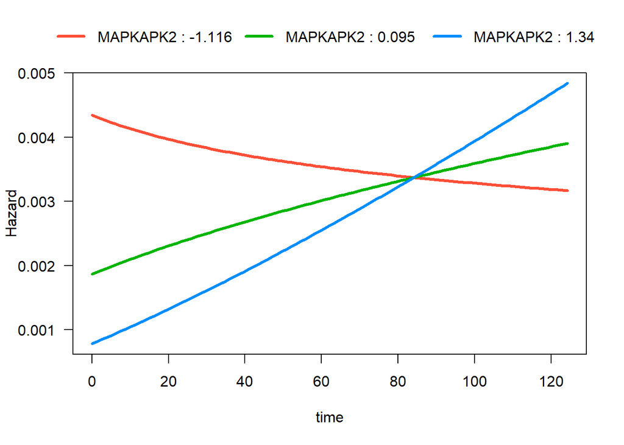

[output not shown]

[output cut: 9108 more lines]

```r
tv_model_viz <- fitSmoothHazard( censor ~ Age+Sex+Smoking+Stage.simp+MAPKAPK2*log(0.5*time+20), data=MK2_valid_t, time="time")

plot(tv_model_viz, hazard.params = list(xvar="time", by="MAPKAPK2", alpha=1,breaks=3,ylab="Hazard"))
```

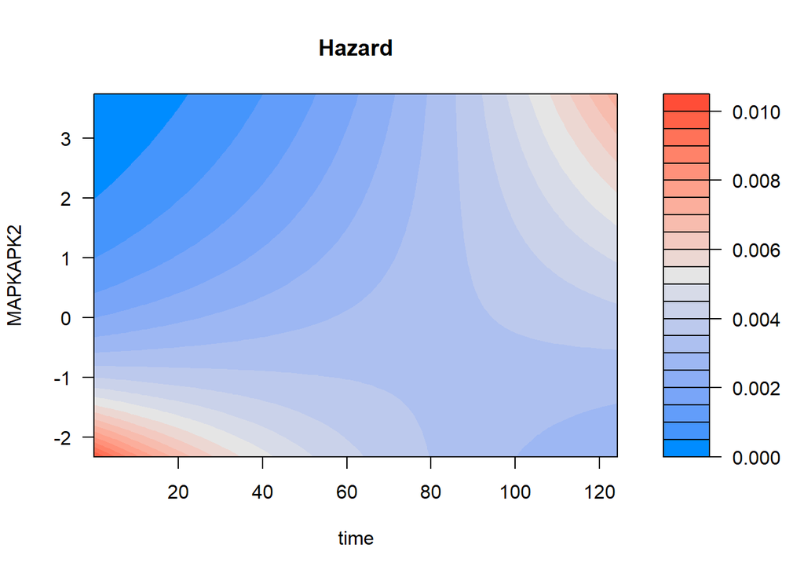

```r
visreg2d(tv_model_viz,
         xvar = "time",
         yvar = "MAPKAPK2",
         trans = exp,
         print.cond = TRUE,
         zlab = "Hazard",
         plot.type = "image")
```

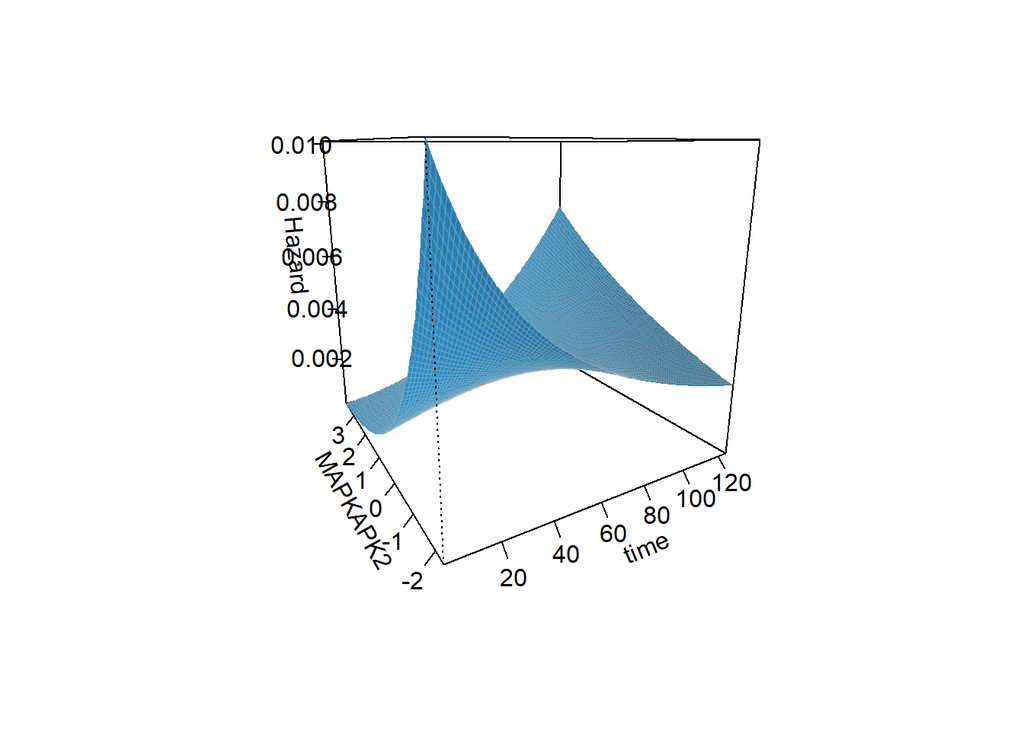

```r
visreg2d(tv_model_viz,
         xvar = "time",
         yvar = "MAPKAPK2",
         trans = exp,
         print.cond = TRUE,
         zlab = "Hazard",
         plot.type = "persp")
```

## Jackknifing the log(t) time transform function coefficients

So, we just sort of picked the a and b values for the term log(a*t+b). Here we do some jackknifing to make sure that some flexibility in these values doesn’t substantially change the outcomes of these models.

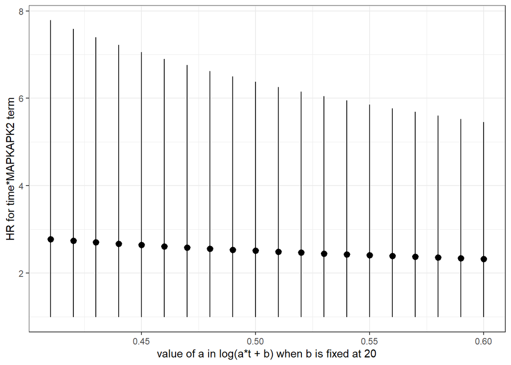

```r
JackKnife_logt <- function(a,b){
model <- coxph(Surv(time, censor) ~ Age+Sex+Smoking+Stage.simp+MAPKAPK2+tt(MAPKAPK2), id=Sample.ID, tt=function(x,t,...) x*log(a*t+b), data=MK2_valid_t2)
return(coef(model)[6])
}
JackKnife_logt_lci <- function(a,b){
model <- coxph(Surv(time, censor) ~ Age+Sex+Smoking+Stage.simp+MAPKAPK2+tt(MAPKAPK2), id=Sample.ID, tt=function(x,t,...) x*log(a*t+b), data=MK2_valid_t2)
return(confint(model)[6])
}
JackKnife_logt_uci <- function(a,b){
model <- coxph(Surv(time, censor) ~ Age+Sex+Smoking+Stage.simp+MAPKAPK2+tt(MAPKAPK2), id=Sample.ID, tt=function(x,t,...) x*log(a*t+b), data=MK2_valid_t2)
return(confint(model)[12])
}

a_vals <- as.data.frame(seq(0.41,0.6,0.01))
colnames(a_vals) <- c("a_vals")
tv_jk <- a_vals
tv_jk$b_vals <- seq(15.5,25,0.5)
MK2_valid_t2 <<- MK2_valid_t
tv_jk$coefficient <- mapply(JackKnife_logt, as.numeric(tv_jk$a_vals), 20)
tv_jk$coefficient_lci <- mapply(JackKnife_logt_lci, as.numeric(tv_jk$a_vals),20)
tv_jk$coefficient_uci <- mapply(JackKnife_logt_uci, as.numeric(tv_jk$a_vals), 20)


ggplot(tv_jk, aes(x=a_vals, y=exp(coefficient), ymin=exp(coefficient_lci), ymax=exp(coefficient_uci)))+geom_point()+geom_pointrange()+theme_bw()+ylab("HR for time*MAPKAPK2 term")+xlab("value of a in log(a*t + b) when b is fixed at 20")
```

[figure not shown]

```r
tv_jk$coefficient_b <- mapply(JackKnife_logt,0.5, as.numeric(tv_jk$b_vals))
tv_jk$coefficient_b_lci <- mapply(JackKnife_logt_lci, 0.5,as.numeric(tv_jk$b_vals))
tv_jk$coefficient_b_uci <- mapply(JackKnife_logt_uci, 0.5, as.numeric(tv_jk$b_vals))

ggplot(tv_jk, aes(x=b_vals, y=coefficient_b, ymin=coefficient_b_lci, ymax=coefficient_b_uci))+geom_point()+geom_pointrange()+theme_bw()+ylab("HR for time*MAPKAPK2 term")+xlab("Value of b in log(a*t+b) when a is fixed at 0.5")
```